# Weekly homework 7

Alina Kereszt

2022-11-07

## Task

Clone the repository at https://github.com/Digital-Methods-HASS/WebscrapingPoliceKillings and depending on your familiarity with R, either

1. adapt the web-scraping example to scrape homicide data from FBI site and produce a meaningful report on how homicide trends evolve around US in relation to this urban unrest

or

2. use the rvest library to scrape data of your interest (football statistics in Wikipedia?, gender representatives in different governments? global population by country in https://www.worldometers.info/world-population/population-by-country/ )

or

3. produce data visualisations that shed light on another interesting aspect of the police killing data

Submit both the .rmd and the rendered .html files to your au###### github repository and paste link here.

## Solution

One of the consistent contributors to my messed-up sleeping schedule is my propensity for spiraling down into Wikipedia rabbit holes. One of my recent such journeys was about supercentenarians, i.e. people who lived to be significantly older than 100 years. So, I decided to choose task 2) and scrape some data about the oldest people ever to have lived in order to learn a little more than what Wikipedia was offering.

The data is valid for 7 November, 2022.

### Scraping the data

```r
# get url
url <- "https://en.wikipedia.org/wiki/List_of_the_verified_oldest_people"

# get website html
url_html <- read_html(url)

# extract all table-like objects from html
table <- url_html %>%
  html_nodes("table") %>%
  html_table()

# inspect structure of object
str(table)
```

```
## List of 3
##  $ : tibble [101 × 6] (S3: tbl_df/tbl/data.frame)
##   ..$ Rank                        : int [1:101] 1 2 3 4 5 6 7 8 9 10 ...
##   ..$ Name                        : chr [1:101] "Jeanne Calment[7]" "Kane Tanaka[6]" "Sarah Knauss[9]" "Lucile Randon[6]" ...
##   ..$ Birth date                  : chr [1:101] "21 February 1875" "2 January 1903" "24 September 1880" "11 February 1904" ...
##   ..$ Death date                  : chr [1:101] "4 August 1997" "19 April 2022[8]" "30 December 1999" "Living" ...
##   ..$ Age                         : chr [1:101] "122 years, 164 days[b]" "119 years, 107 days" "119 years, 97 days" "118 years, 269 days" ...
##   ..$ Place of death  or residence: chr [1:101] "France" "Japan" "United States" "France" ...
##  $ : tibble [100 × 6] (S3: tbl_df/tbl/data.frame)
##   ..$ Rank                        : int [1:100] 1 2 3 4 5 6 7 8 9 10 ...
##   ..$ Name[a]                     : chr [1:100] "Jiroemon Kimura" "Christian Mortensen" "Emiliano Mercado del Toro" "Mathew Beard" ...
##   ..$ Birth date                  : chr [1:100] "19 April 1897" "16 August 1882" "21 August 1891" "9 July 1870" ...
##   ..$ Death date                  : chr [1:100] "12 June 2013" "25 April 1998" "24 January 2007" "16 February 1985" ...
##   ..$ Age                         : chr [1:100] "116 years, 54 days" "115 years, 252 days" "115 years, 156 days" "114 years, 222 days" ...
##   ..$ Place of death  or residence: chr [1:100] "Japan" "United States[b]" "Puerto Rico" "United States" ...
##  $ : tibble [6 × 2] (S3: tbl_df/tbl/data.frame)
##   ..$ .mw-parser-output .navbar{display:inline;font-size:88%;font-weight:normal}.mw-parser-output .navbar-collapse{float:left;text-align:left}.mw-parser-output .navbar-boxtext{word-spacing:0}.mw-parser-output .navbar ul{display:inline-block;white-space:nowrap;line-height:inherit}.mw-parser-output…
##   ..$ .mw-parser-output .navbar{display:inline;font-size:88%;font-weight:normal}.mw-parser-output .navbar-collapse{float:left;text-align:left}.mw-parser-output .navbar-boxtext{word-spacing:0}.mw-parser-output .navbar ul{display:inline-block;white-space:nowrap;line-height:inherit}.mw-parser-output…
```

```r
# extract the tables i want
women <- table[[1]]
men <- table[[2]]
```

### Cleaning up the data

```r
##### Column names are unwieldy.
# clean up column names
colnames(women) <- c("rank_sex",
                     "name",
                     "birth_date",
                     "death_date",
                     "age",
                     "country")
colnames(men) <- c("rank_sex",
                   "name",
                   "birth_date",
                   "death_date",
                   "age",
                   "country")

##### The data for women and men are in separate tables.
# create dummy variable for sex
women$sex <- "F"
men$sex <- "M"

# merge tables
df <- rbind(women, men)

##### There are within-cell references to external data.
# the structure of these is either [1] or [a]
# regex to replace with nothing
# i could technically write a function for this, but manually applying it to
# all columns takes all of 1 minute...
df$name <- str_replace_all(df$name,
                           "\\[\\w+\\]",
                           "")
df$birth_date <- str_replace_all(df$birth_date,
                           "\\[\\w+\\]",
                           "")
df$death_date <- str_replace_all(df$death_date,
                           "\\[\\w+\\]",
                           "")
df$age <- str_replace_all(df$age,
                           "\\[\\w+\\]",
                           "")
df$country <- str_replace_all(df$country,
                           "\\[\\w+\\]",
                           "")

##### There is a tidier way to indicate which people are still alive.
# create dummy variable for alive status
df$status <- "dead"
df$status[df$death_date == "Living"] <- "alive"

##### I would like to work with the supercentenarians' birth and death years.
# get years simply by deleting everything else with regex
df$birth_year <- str_replace_all(df$birth_date,
                                 "\\d+\\s\\w+\\s",
                                 "")
df$death_year <- str_replace_all(df$death_date,
                                 "\\d+\\s\\w+\\s",
                                 "")

# death year is NA for those that are alive
df$death_year[df$death_year == "Living"] <- NA

##### Age is unwieldy to work with.
# separate into years and days
df <- df %>%
  separate(age,
           c("age_year",
             "age_days"),
           ", ")

# remove text parts with regex
df$age_year <- str_replace_all(df$age_year,
                               "\\s\\w+",
                               "")
df$age_days <- str_replace_all(df$age_days,
                               "\\s\\w+",
                               "")

# ensure encoding
df$age_year <- as.numeric(df$age_year)
df$age_days <- as.numeric(df$age_days)

# assuming a year is 365 days, find decimal value of days
df$age_days <- round(df$age_days / 365,
                     2)

# pull age into single variable
df$age <- df$age_year + df$age_days

# remove unnecessary columns
df <- df[,-c(5, 6)]

##### The people should be ranked overall, too, not just by sex.
df <- df %>%
  mutate(rank_overall = dense_rank(desc(age)))

##### The proper encoding of variables isn't ensured.
df$country <- as.factor(df$country)
df$sex <- as.factor(df$sex)
df$status <- as.factor(df$status)
df$birth_year <- as.numeric(df$birth_year)
df$death_year <- as.numeric(df$death_year)

##### Let's see what the data looks like!
head(df,
     n = 10)
```

```
## # A tibble: 10 × 11
##    rank_sex name      birth…¹ death…² country sex   status birth…³ death…⁴   age
##       <int> <chr>     <chr>   <chr>   <fct>   <fct> <fct>    <dbl>   <dbl> <dbl>
##  1        1 Jeanne C… 21 Feb… 4 Augu… France  F     dead      1875    1997  122.
##  2        2 Kane Tan… 2 Janu… 19 Apr… Japan   F     dead      1903    2022  119.
##  3        3 Sarah Kn… 24 Sep… 30 Dec… United… F     dead      1880    1999  119.
##  4        4 Lucile R… 11 Feb… Living  France  F     alive     1904      NA  119.
##  5        5 Nabi Taj… 4 Augu… 21 Apr… Japan   F     dead      1900    2018  118.
##  6        6 Marie-Lo… 29 Aug… 16 Apr… Canada  F     dead      1880    1998  118.
##  7        7 Violet B… 10 Mar… 15 Sep… Jamaica F     dead      1900    2017  118.
##  8        8 Emma Mor… 29 Nov… 15 Apr… Italy   F     dead      1899    2017  117.
##  9        9 Chiyo Mi… 2 May … 22 Jul… Japan   F     dead      1901    2018  117.
## 10       10 Misao Ok… 5 Marc… 1 Apri… Japan   F     dead      1898    2015  117.
## # … with 1 more variable: rank_overall <int>, and abbreviated variable names
## #   ¹birth_date, ²death_date, ³birth_year, ⁴death_year
```

### Making some visualizations

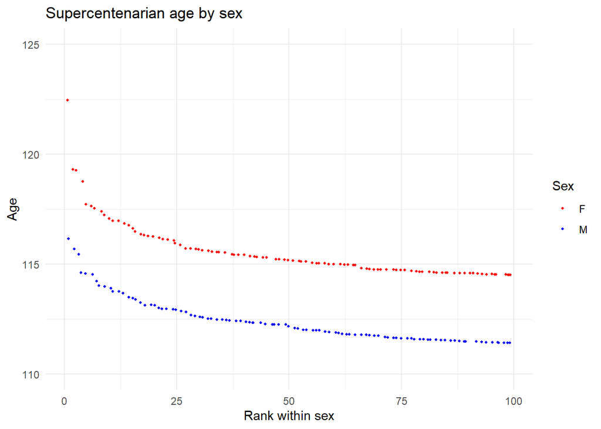

```r
ggplot(df,
       aes(x = rank_sex,
           y = age,
           color = sex)) +
  geom_point(size = 0.75,
             position = "jitter") + # jitter bc some are the same age
  ylim(110, 125) +
  labs(title = "Supercentenarian age by sex",
       x = "Rank within sex",
       y = "Age",
       color = "Sex") +
  scale_color_manual(values = c("red",
                                "blue"),
                     labels = c("F",
                                "M")) +
  theme_minimal()
```

The above plot shows that the oldest verified female supercentenarians are older than the male ones - the verified oldest man ever to have lived only grew to be as old as approximately the 20th oldest woman ever to have lived.

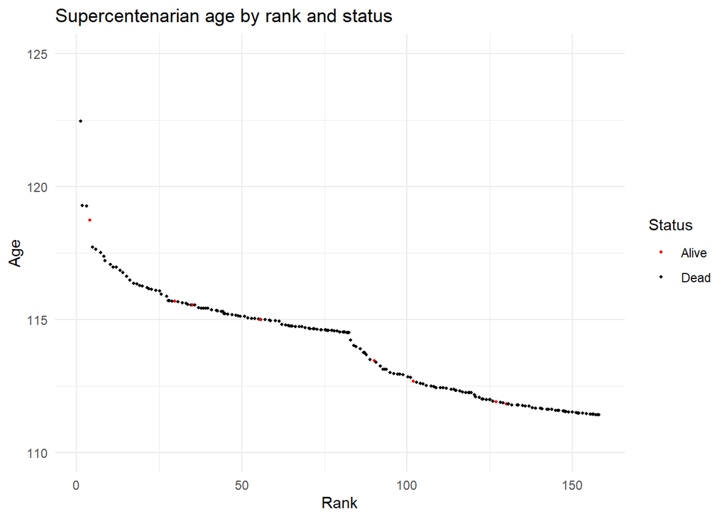

```r
ggplot(df,
       aes(x = rank_overall,
           y = age,
           color = status)) +
  geom_point(size = 0.75,
             position = 'jitter') + # jitter bc some are the same age
  ylim(110, 125) +
  labs(title = "Supercentenarian age by rank and status",
       x = "Rank",
       y = "Age",
       color = "Status") +
  scale_color_manual(values = c("red",
                                "black"),
                     labels = c("Alive",
                                "Dead")) +
  theme_minimal()
```

The above plot shows that most of the verified oldest people ever to have lived have already passed away. Quite a few of them are still alive (and will become even older), but they are not the ultimate record-holders (yet?).

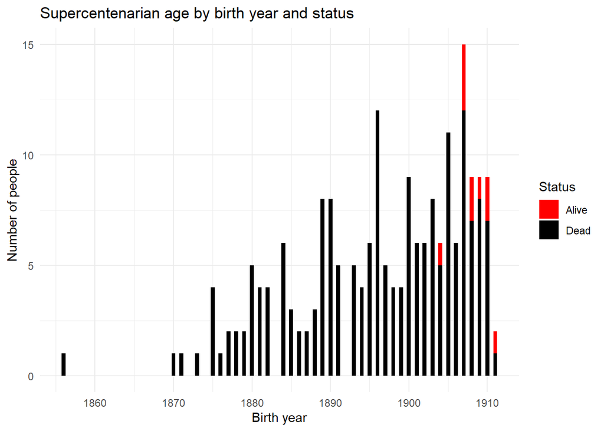

```r
ggplot(df,
       aes(x = birth_year,
           fill = status)) +
  geom_histogram(binwidth = 0.5) + # ensure plotting is by year
  labs(title = "Supercentenarian age by birth year and status",
       x = "Birth year",
       y = "Number of people",
       fill = "Status") +
  scale_fill_manual(values = c("red",
                               "black"),
                    labels = c("Alive",
                               "Dead")) +
  theme_minimal()
```

The above plot shows that most of the verified oldest people ever to have lived were born after 1850 - this is likely when record-keeping became sufficiently accurate to verify claims of extremely old age. The supercentenarians that are still alive are, for obvious reasons, towards the end of the distribution.

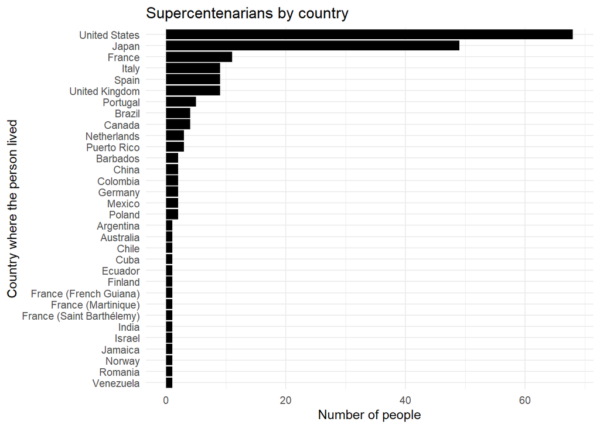

```r
ggplot(df,
       aes(x = fct_rev(fct_infreq(country)))) + # reorder x by frequency
  geom_bar(fill = "black") +
  coord_flip() + # flip x and y axis for more intuitive plot
  labs(title = "Supercentenarians by country",
       x = "Country where the person lived",
       y = "Number of people",
       fill = "Status") +
  theme_minimal()
```

The above plot shows that the of the 201 oldest people ever to have lived, most were in the USA, Japan and France. This plot does not take into account the countries’ population, though, so more data would need to be sourced to see which places have the largest concentration of supercentenarians.